# 09_QuantLing_Section

Eric Wilbanks

4/03/2020 - 4/06/2020

## 1. Goals for Section

1. FAQs - The New Normal
2. HW3 Overview and Questions
3. Model-Predicted Likelihood and Likelihood Ratio Test
4. Hierarchical Models

## 2. FAQs

1. **What if I’m dealing with a sick family member, or lost job, or any other source of stress?**
- First, don’t fall into the trap of idolizing productivity during this period! You shouldn’t feel pressured to continue on as normal, allow yourself to focus on your mental and physical wellbeing.

Things that I would rather you do every day than worry about section: 1) walk outside (while distancing) for 20 minutes 2) drink some more water 3) try out a yoga video on youtube (there are thousands) 4) drink some more water 5) zoom/skype with your family 6) continue to drink water 7) take a nap

This course priority should be lower for you. Take some time to take care of yourself and your family, and then focus on what you need to do to get a P.

- Second, consider the resources provided by the university:
  - (general support links) https://docs.google.com/spreadsheets/d/1tvkRxcm7bLCUDffHdOYJFZ3JiHZKClPnGFJi41O_P6M/
  - (specific COVID-19 links) https://sa.berkeley.edu/covid19
  - (emergency loans) https://financialaid.berkeley.edu/whats-new-financial-aid-and-scholarships
- Third, consider the resources provided by the state:
  - Financial support options https://www.labor.ca.gov/coronavirus2019/#chart
  - General coronavirus information: https://covid19.ca.gov/
2. **What’s going on with section?**
- attendance is optional; I’ll be posting the materials and video
- meetings at typical times over Zoom; if you want to attend another section, just let me know!
3. **What’s going on with lecture grading?**
- default grading option has changed to P/NP.
- if you want a letter grade, you can change it before May 6
- for LING majors: P/NP grades from this semester will count toward LING major (see Prof. Jenks’ email).

## 3. Other Questions?

## 4. Homework 3 Overview

## 5. Model-Predicted Likelihood and Likelihood Ratio Test

Let’s try breaking out into groups now (if I can get things to work) to think about the following questions:

```
1. What is `model-predicted likelihood`?
2. Say I fit a logistic regression model to predict if it was Rainy or Sunny outside. I work out the inverse-logit and find that I predict 40% rainy and 60% sunny (just intercept model).
  a) What is the model-predicted likelihood of two Sunny days in a row?
  b) What is the model-predicted likelihood of two Rainy days in a row?
  c) What is the model-predicted likelihood of S-R-S?
3. These values are small, which leads to the calculation of Deviance. What is the null hypothesis of likelihood ratio tests between two logistic regression models?
```

## 6. Hierarchical Models

Hierarchical (“Mixed”) Models have both **fixed** predictors (which we’ve been dealing with so far) and **random** predictors.

```
1. At a high level, how are random effects/predictors different from fixed predictors?
2. What types of uses could they have in modeling language data?
```

```
That's a theoretical difference; how are fixed and random effects different in the model?
```

Fixed effects are estimated with complete pooling (e.g., intercept is just estimated grand mean) where as random effects are estimated with **partial pooling** (e.g., estimates of each individual adjustment is weighted by amount of data for that individual level, balanced against estimate grand mean) [[see e.g., http://www.win-vector.com/blog/2017/09/partial-pooling-for-lower-variance-variable-encoding/#more-5245]]

```r
library(lme4)
library(languageR)
data(lexdec)

# subject is fixed effect
m1 <- lm(RT ~ Subject, lexdec)

# subject is random effect
m2 <- lmer(RT ~ (1|Subject), lexdec)

summary(m1)
```

```
##
## Call:
## lm(formula = RT ~ Subject, data = lexdec)
##
## Residuals:
##      Min       1Q   Median       3Q      Max
## -0.43914 -0.12231 -0.02687  0.08769  1.11810
##
## Coefficients:
##             Estimate Std. Error t value Pr(>|t|)
## (Intercept)  6.27773    0.02127 295.119  < 2e-16 ***
## SubjectA2   -0.05735    0.03008  -1.906 0.056761 .
## SubjectA3    0.12000    0.03008   3.989 6.93e-05 ***
## SubjectC     0.04458    0.03008   1.482 0.138548
## SubjectD     0.12834    0.03008   4.266 2.10e-05 ***
## SubjectI    -0.02461    0.03008  -0.818 0.413388
## SubjectJ    -0.02306    0.03008  -0.766 0.443515
## SubjectK    -0.08490    0.03008  -2.822 0.004826 **
## SubjectM1   -0.10452    0.03008  -3.474 0.000525 ***
## SubjectM2    0.25498    0.03008   8.476  < 2e-16 ***
## SubjectP     0.15145    0.03008   5.034 5.32e-07 ***
## SubjectR1    0.02953    0.03008   0.982 0.326446
## SubjectR2    0.19450    0.03008   6.465 1.33e-10 ***
## SubjectR3    0.11517    0.03008   3.828 0.000134 ***
## SubjectS     0.09594    0.03008   3.189 0.001454 **
## SubjectT1    0.08507    0.03008   2.828 0.004743 **
## SubjectT2    0.52976    0.03008  17.610  < 2e-16 ***
## SubjectV     0.30958    0.03008  10.291  < 2e-16 ***
## SubjectW1   -0.01384    0.03008  -0.460 0.645647
## SubjectW2    0.18273    0.03008   6.074 1.55e-09 ***
## SubjectZ     0.32114    0.03008  10.675  < 2e-16 ***
## ---
## Signif. codes:  0 '***' 0.001 '**' 0.01 '*' 0.05 '.' 0.1 ' ' 1
##
## Residual standard error: 0.1891 on 1638 degrees of freedom
## Multiple R-squared:  0.3945, Adjusted R-squared:  0.3871
## F-statistic: 53.36 on 20 and 1638 DF,  p-value: < 2.2e-16
```

```r
summary(m2)
```

```
## Linear mixed model fit by REML ['lmerMod']
## Formula: RT ~ (1 | Subject)
##    Data: lexdec
##
## REML criterion at convergence: -731.1
##
## Scaled residuals:
##     Min      1Q  Median      3Q     Max
## -2.3080 -0.6497 -0.1466  0.4588  5.9060
##
## Random effects:
##  Groups   Name        Variance Std.Dev.
##  Subject  (Intercept) 0.02369  0.1539
##  Residual             0.03575  0.1891
## Number of obs: 1659, groups:  Subject, 21
##
## Fixed effects:
##             Estimate Std. Error t value
## (Intercept)  6.38509    0.03391   188.3
```

```r
# observed mean RT for all subjects
mean(lexdec$RT)
```

```
## [1] 6.38509
```

```r
# observed mean RT for Subject A1
mean(lexdec[lexdec$Subject == 'A1',]$RT)
```

```
## [1] 6.277734
```

```r
# estimate for A1 as fixed effect:
unname(m1$coefficients[1])
```

```
## [1] 6.277734
```

```r
# estimate for A1 as random effect:
unname(fixef(m2) + ranef(m2)$Subject['A1',])
```

```
## [1] 6.279745
```

```r
###################
# in single predictor model, fixed estimates are based on complete pooling of data
# this is why the prediction for A1 as a fixed predictor (m1) is equal to the observed mean for A1 RT
# in a single predictor model, random estimates are based on partial pooling (not just average of A1, mix of overall mean and sub-group mean)
# the estimate for A1 is biased away from the observed A1 mean and towards the overall group mean (because of partial pooling)
###################
```

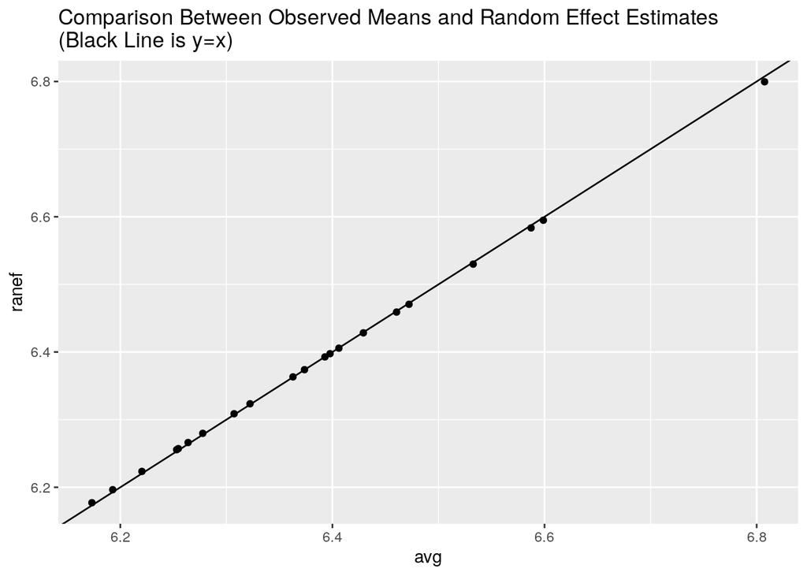

We can tell that the Subject random effects to the left seem to be higher than the identity line (higher than the observed mean for that subject), while the random effects to the right seem to be lower than the identity line (lower than the observed mean for that subject).

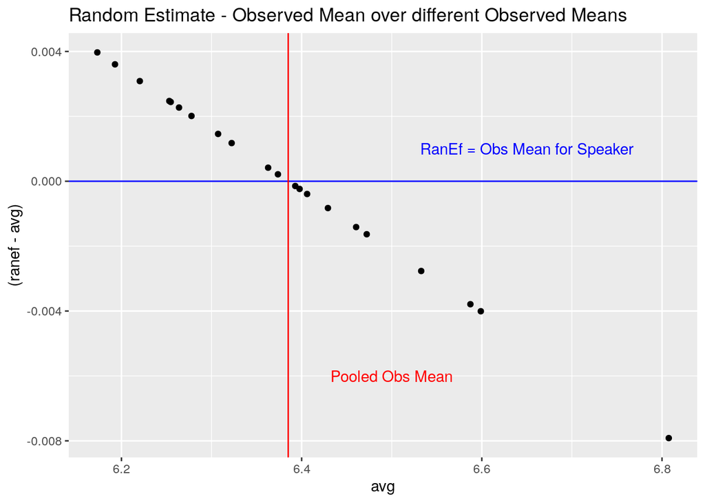

We can see the same pattern a different way. Here, some values on the left are positive (RanEf > Obs Mean Speaker). Some values on the right are negative (RanEf < Obs Mean Speaker).

So what we’re seeing is the effects of partial-pooling: the strength of the random effects are **shrunk** towards the overall grand mean, compared to what they would be if they were fixed effects.

This corresponds to our theoretical difference between fixed and random effects: random effects are a random sample/subset from a larger population, and therefore we are more conservative about our estimates for them and rely some on the grand mean (partial pooling).